# Machine Learning Coursera

Jakob Graessel

28 Dezember 2018

# Coursera Machine Learning - Course Project

Analysis of Fitness Data to predict outcome *classe* (way in which training session was performed) by using Machine Learning algorithms and other variables provided in the data set.

## 1. Data Cleaning

First load **caret** and **ggplot2** packages:

```r
library(caret)
library(ggplot2)
```

Then read training data and look at data structure (only first 20 columns to limit output):

```r
pml_complete <- read.csv("pml-training.csv")
str(pml_complete[,1:20])
```

```
## 'data.frame':    19622 obs. of  20 variables:
##  $ X                   : int  1 2 3 4 5 6 7 8 9 10 ...
##  $ user_name           : Factor w/ 6 levels "adelmo","carlitos",..: 2 2 2 2 2 2 2 2 2 2 ...
##  $ raw_timestamp_part_1: int  1323084231 1323084231 1323084231 1323084232 1323084232 1323084232 1323084232 1323084232 1323084232 1323084232 ...
##  $ raw_timestamp_part_2: int  788290 808298 820366 120339 196328 304277 368296 440390 484323 484434 ...
##  $ cvtd_timestamp      : Factor w/ 20 levels "02/12/2011 13:32",..: 9 9 9 9 9 9 9 9 9 9 ...
##  $ new_window          : Factor w/ 2 levels "no","yes": 1 1 1 1 1 1 1 1 1 1 ...
##  $ num_window          : int  11 11 11 12 12 12 12 12 12 12 ...
##  $ roll_belt           : num  1.41 1.41 1.42 1.48 1.48 1.45 1.42 1.42 1.43 1.45 ...
##  $ pitch_belt          : num  8.07 8.07 8.07 8.05 8.07 8.06 8.09 8.13 8.16 8.17 ...
##  $ yaw_belt            : num  -94.4 -94.4 -94.4 -94.4 -94.4 -94.4 -94.4 -94.4 -94.4 -94.4 ...
##  $ total_accel_belt    : int  3 3 3 3 3 3 3 3 3 3 ...
##  $ kurtosis_roll_belt  : Factor w/ 397 levels "","-0.016850",..: 1 1 1 1 1 1 1 1 1 1 ...
##  $ kurtosis_picth_belt : Factor w/ 317 levels "","-0.021887",..: 1 1 1 1 1 1 1 1 1 1 ...
##  $ kurtosis_yaw_belt   : Factor w/ 2 levels "","#DIV/0!": 1 1 1 1 1 1 1 1 1 1 ...
##  $ skewness_roll_belt  : Factor w/ 395 levels "","-0.003095",..: 1 1 1 1 1 1 1 1 1 1 ...
##  $ skewness_roll_belt.1: Factor w/ 338 levels "","-0.005928",..: 1 1 1 1 1 1 1 1 1 1 ...
##  $ skewness_yaw_belt   : Factor w/ 2 levels "","#DIV/0!": 1 1 1 1 1 1 1 1 1 1 ...
##  $ max_roll_belt       : num  NA NA NA NA NA NA NA NA NA NA ...
##  $ max_picth_belt      : int  NA NA NA NA NA NA NA NA NA NA ...
##  $ max_yaw_belt        : Factor w/ 68 levels "","-0.1","-0.2",..: 1 1 1 1 1 1 1 1 1 1 ...
```

Turning levels/values of some variables (*kurtosis_yaw_dumbbell*, *skewness_roll_dumbbell* etc.) into meaningful NA’s, and exclude variables with more than 95% NA’s, as splitting data afterwards into train and test set can lead to varibles with only missing values. Furthermore imputation is also not an option because there are too few complete cases in the data, which can be used for a nearest neighbour imputation approach.

```r
pml_cleaned <- pml_complete
pml_cleaned[pml_cleaned==""] <- NA
pml_cleaned[pml_cleaned=="#DIV/0!"] <- NA

## turn factor variables into character/numeric
pml_cleaned[, sapply(pml_cleaned, is.factor)]<- sapply(pml_cleaned[,sapply(pml_cleaned, is.factor)],
                                                       function(x) levels(x)[x])

## number of variables with more than 95% missing values:
sum(sapply(pml_cleaned, function(x) sum(is.na(x))/length(x) > 0.95))
```

```
## [1] 100
```

```r
## exclude variables from data
pml_reduced <- pml_cleaned[,sapply(pml_cleaned, function(x) sum(is.na(x))/length(x) < 0.95)]
```

## 2. Data Splitting

Split data into train (60%), test (20%) and validation sets (20%) and set seed for reproducability.

```r
set.seed(270514)
inTrain <- caret::createDataPartition(y=pml_reduced$classe,
                               p=.6, list=F)
training <- pml_reduced[inTrain,]
validate_testing <- pml_reduced[-inTrain, ]

inValidation <- caret::createDataPartition(y=validate_testing$classe,
                                    p=.5, list=F)
testing <- validate_testing[-inValidation,]
validation <- validate_testing[inValidation,]
```

## 3. Analyse Trainig Data

First look at index variable if there’s a relationship between *index* and *classe* variable:

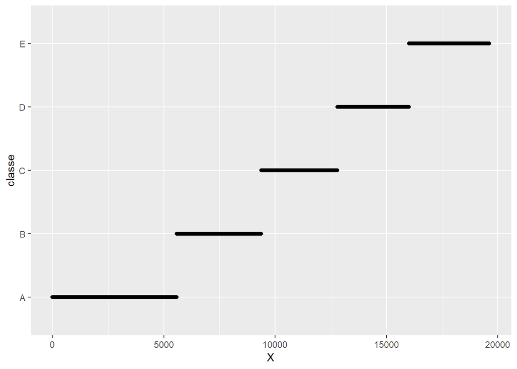

```r
ggplot2::qplot(X, classe, data=training)
```

Exclude *index* variable and for safety reason also *user_name* from training data. Furthermore look if outcome is dependent from time variables (*raw_timestamp_part_1*, *cvtd_timestamp*, *new_window*, etc):

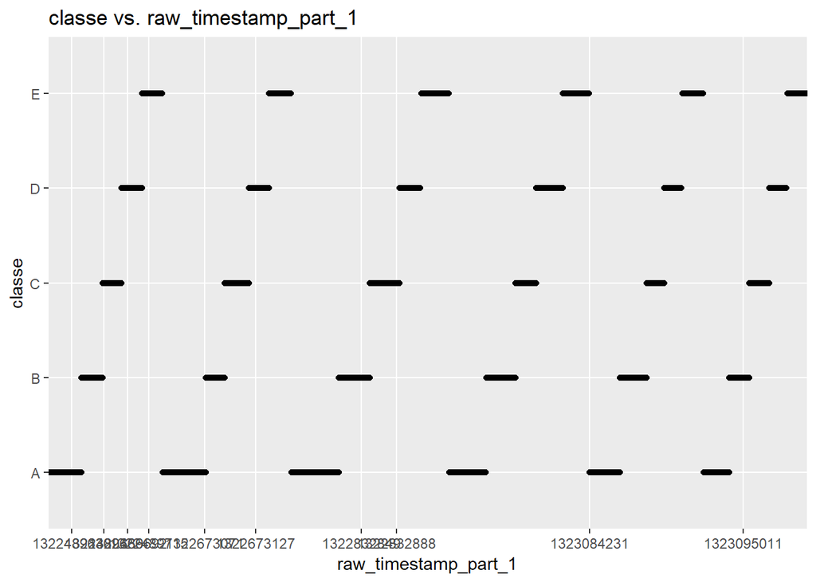

Time variables also influence outcome, therefore they should also be excluded from model building.

```r
training <- training[, !colnames(training) %in% c("X", "user_name", "raw_timestamp_part_1",
                                                  "raw_timestamp_part_2", "cvtd_timestamp",
                                                  "new_window", "num_window")]
```

## 4. Model Building

Build three different models: Classification Tree (**rpart**), Random Forest (**rf**) and Generalized Boosted Models (**gbm**). Use all other variables as predictors and use default options:

```r
rpart_obj <- train(classe~., method="rpart", data =training)

rf_obj <- train(classe~., method="rf",data = training)

gbm_obj <- train(classe~., method="gbm", data=training)
```

Further analysis of all three models: first look at Classification Tree -what are the features used as splitting criterias:

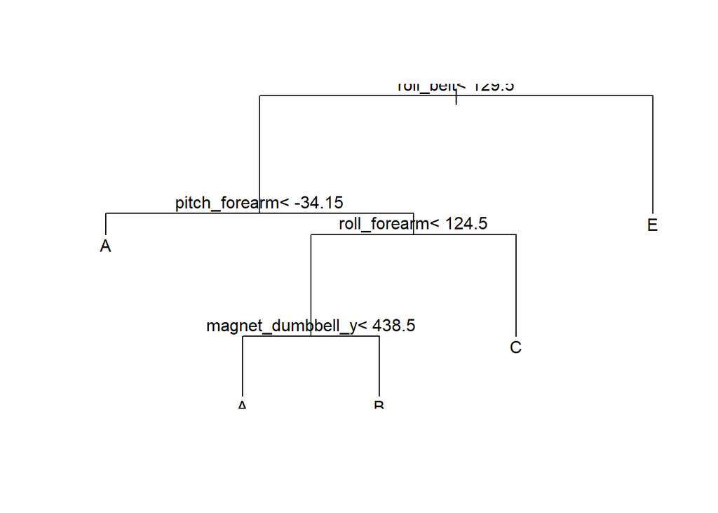

```r
plot(rpart_obj$finalModel)
text(rpart_obj$finalModel)
```

Look at Random Forest Model - which features are the most important ones (TOP 5):

```r
imp <- rf_obj$finalModel$importance
imp[order(imp, decreasing = T), ][1:5]
```

```
##         roll_belt          yaw_belt magnet_dumbbell_z magnet_dumbbell_y
##          419.7187          346.4854          314.2927          304.0377
##        pitch_belt
##          299.9467
```

Results of Generalised Boosted Model:

```r
gbm_obj$results
```

```
##   shrinkage interaction.depth n.minobsinnode n.trees  Accuracy     Kappa
## 1       0.1                 1             10      50 0.7485979 0.6813014
## 4       0.1                 2             10      50 0.8486611 0.8081710
## 7       0.1                 3             10      50 0.8887146 0.8590269
## 2       0.1                 1             10     100 0.8118061 0.7617074
## 5       0.1                 2             10     100 0.8991568 0.8722961
## 8       0.1                 3             10     100 0.9342135 0.9167111
## 3       0.1                 1             10     150 0.8466568 0.8058677
## 6       0.1                 2             10     150 0.9238254 0.9035557
## 9       0.1                 3             10     150 0.9536070 0.9412749
##    AccuracySD     KappaSD
## 1 0.007325228 0.009217671
## 4 0.006799180 0.008490465
## 7 0.005170603 0.006478362
## 2 0.006647139 0.008281637
## 5 0.004776686 0.005983811
## 8 0.004031993 0.005106380
## 3 0.005001656 0.006286698
## 6 0.003909597 0.004943453
## 9 0.003666163 0.004639398
```

## 5. Model Performance on test data

Next use test set and predict outcomes by using the three different models and compare them with the real values:

```r
## get prediction on test data
prediction_rf <- predict(rf_obj, testing)
prediction_rpart <- predict(rpart_obj, testing)
prediction_gbm <- predict(gbm_obj, testing)

# look at table of prediction vs true
table(prediction_rf, testing$classe)
```

```
##
## prediction_rf    A    B    C    D    E
##             A 1116    3    0    0    0
##             B    0  755    1    0    0
##             C    0    1  680   11    0
##             D    0    0    3  632    0
##             E    0    0    0    0  721
```

```r
table(prediction_rpart, testing$classe)
```

```
##
## prediction_rpart   A   B   C   D   E
##                A 991 321 317 302 113
##                B  18 202  13 112  45
##                C  89 236 354 229 247
##                D   0   0   0   0   0
##                E  18   0   0   0 316
```

```r
table(prediction_gbm, testing$classe)
```

```
##
## prediction_gbm    A    B    C    D    E
##              A 1102   25    0    0    0
##              B    7  714   16    2    6
##              C    3   19  662   17    4
##              D    3    1    6  622   10
##              E    1    0    0    2  701
```

Classification tree seem to have the worst predictions in all classes, whereas random forest and gbm have very good predictions. What are the accuracy rates for all three models?

```r
## calculate accuracy on test data:
library(caret)
# Random Forest:
cfm_rf <- confusionMatrix(table(prediction_rf, testing$classe))
cfm_rf$overall["Accuracy"]
```

```
##  Accuracy
## 0.9951568
```

```r
# Classification Tree:
cfm_rpart <- confusionMatrix(table(prediction_rpart, testing$classe))
cfm_rpart$overal["Accuracy"]
```

```
##  Accuracy
## 0.4748917
```

```r
# Generalised Boosted Model
cfm_gbm<- confusionMatrix(table(prediction_gbm, testing$classe))
cfm_gbm$overal["Accuracy"]
```

```
##  Accuracy
## 0.9689014
```

Random Forest has the best accuracy on test set. To visualise performance of all three models use scatterplot of the two most important predictors for Random Forest model (*yaw_belt* & *roll_belt*). The different shapes of the data points indicate the true *classe* value in the test set, whereas the color is used to see wether the outcome was predicted right by the model (green=right prediction, red=false prediction):

```r
testing$classe_prediction_rf <- prediction_rf
testing$classe_pred_rf_acc <- (testing$classe == testing$classe_prediction_rf) *1

testing$classe_prediction_rpart <- prediction_rpart
testing$classe_pred_rpart_acc <- (testing$classe == testing$classe_prediction_rpart) *1

testing$classe_prediction_gbm <- prediction_gbm
testing$classe_pred_gbm_acc <- (testing$classe == testing$classe_prediction_gbm) *1
```

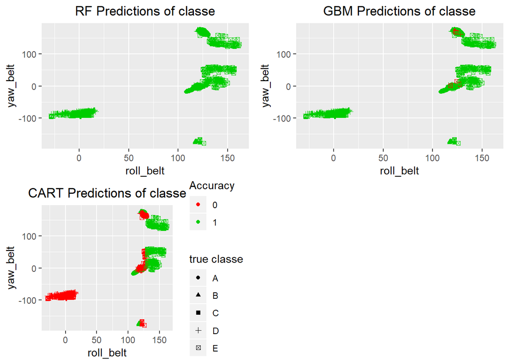

## 6. Validate Random Forest Model

Finally use Random Forest Model for Validation Set, to see if results are stable:

```r
validation_rf <- predict(rf_obj, validation)
table(validation_rf, validation$classe)
```

```
##
## validation_rf    A    B    C    D    E
##             A 1114    4    0    0    0
##             B    2  754    1    0    0
##             C    0    1  683   19    0
##             D    0    0    0  624    3
##             E    0    0    0    0  718
```

```r
cfm_rf_validate <- caret::confusionMatrix(table(validation_rf, validation$classe))
cfm_rf_validate$overall["Accuracy"]
```

```
##  Accuracy
## 0.9923528
```

## 7. Quiz Prediction

Model has stable predictions also for validation set, use Random Forest for prediction of final test data:

```r
quiz_data <- read.csv("pml-testing.csv")
predict(rf_obj, quiz_data)
```

```
##  [1] B A B A A E D B A A B C B A E E A B B B
## Levels: A B C D E
```